# Homework #4

Seyedehbahareh Hashemimovahed

2/27/2022

## Cars and mileage

#### Due: 2/27/2022 before 11:59pm. Submit in Canvas (file upload).

In this homework we will use the `mpg` data set, you can access the data by loading the package `ggplot2` into your R session by executing the command `library(ggplot2)`. The `mpg` data includes information about fuel economy of popular car models for the years 1999 and 2008 as collected by the US Environmental Protection Agency.

Most exercises are from the ggplot2 book section 2.2.1. You might find it helpful for working on the homework to read through this section.

```r
head(mpg)
```

```
## # A tibble: 6 × 11
##   manufacturer model displ  year   cyl trans      drv     cty   hwy fl    class
##   <chr>        <chr> <dbl> <int> <int> <chr>      <chr> <int> <int> <chr> <chr>
## 1 audi         a4      1.8  1999     4 auto(l5)   f        18    29 p     compa…
## 2 audi         a4      1.8  1999     4 manual(m5) f        21    29 p     compa…
## 3 audi         a4      2    2008     4 manual(m6) f        20    31 p     compa…
## 4 audi         a4      2    2008     4 auto(av)   f        21    30 p     compa…
## 5 audi         a4      2.8  1999     6 auto(l5)   f        16    26 p     compa…
## 6 audi         a4      2.8  1999     6 manual(m5) f        18    26 p     compa…
```

1. Download the RMarkdown file with these homework instructions to use as a template for your work. Make sure to replace “Your Name” in the YAML with your name.
2. List five functions that you could use to get more information about the mpg dataset.

```r
head(mpg) #allows us to vie the objects in the data
```

```
## # A tibble: 6 × 11
##   manufacturer model displ  year   cyl trans      drv     cty   hwy fl    class
##   <chr>        <chr> <dbl> <int> <int> <chr>      <chr> <int> <int> <chr> <chr>
## 1 audi         a4      1.8  1999     4 auto(l5)   f        18    29 p     compa…
## 2 audi         a4      1.8  1999     4 manual(m5) f        21    29 p     compa…
## 3 audi         a4      2    2008     4 manual(m6) f        20    31 p     compa…
## 4 audi         a4      2    2008     4 auto(av)   f        21    30 p     compa…
## 5 audi         a4      2.8  1999     6 auto(l5)   f        16    26 p     compa…
## 6 audi         a4      2.8  1999     6 manual(m5) f        18    26 p     compa…
```

```r
colnames(mpg) #gives us the name of Columns in the mpg dataset
```

```
##  [1] "manufacturer" "model"        "displ"        "year"         "cyl"
##  [6] "trans"        "drv"          "cty"          "hwy"          "fl"
## [11] "class"
```

```r
unique(mpg[c("cty")]) #Get the different city that are in datasets
```

```
## # A tibble: 21 × 1
##      cty
##    <int>
##  1    18
##  2    21
##  3    20
##  4    16
##  5    19
##  6    15
##  7    17
##  8    14
##  9    11
## 10    13
## # … with 11 more rows
```

```r
summary(mpg) #gives us a info summary of the datasets
```

```
##  manufacturer          model               displ            year
##  Length:234         Length:234         Min.   :1.600   Min.   :1999
##  Class :character   Class :character   1st Qu.:2.400   1st Qu.:1999
##  Mode  :character   Mode  :character   Median :3.300   Median :2004
##                                        Mean   :3.472   Mean   :2004
##                                        3rd Qu.:4.600   3rd Qu.:2008
##                                        Max.   :7.000   Max.   :2008
##       cyl           trans               drv                 cty
##  Min.   :4.000   Length:234         Length:234         Min.   : 9.00
##  1st Qu.:4.000   Class :character   Class :character   1st Qu.:14.00
##  Median :6.000   Mode  :character   Mode  :character   Median :17.00
##  Mean   :5.889                                         Mean   :16.86
##  3rd Qu.:8.000                                         3rd Qu.:19.00
##  Max.   :8.000                                         Max.   :35.00
##       hwy             fl               class
##  Min.   :12.00   Length:234         Length:234
##  1st Qu.:18.00   Class :character   Class :character
##  Median :24.00   Mode  :character   Mode  :character
##  Mean   :23.44
##  3rd Qu.:27.00
##  Max.   :44.00
```

```r
filter(mpg, year == 1999) #we can filter out data based on the condition.
```

```
## # A tibble: 117 × 11
##    manufacturer model      displ  year   cyl trans drv     cty   hwy fl    class
##    <chr>        <chr>      <dbl> <int> <int> <chr> <chr> <int> <int> <chr> <chr>
##  1 audi         a4           1.8  1999     4 auto… f        18    29 p     comp…
##  2 audi         a4           1.8  1999     4 manu… f        21    29 p     comp…
##  3 audi         a4           2.8  1999     6 auto… f        16    26 p     comp…
##  4 audi         a4           2.8  1999     6 manu… f        18    26 p     comp…
##  5 audi         a4 quattro   1.8  1999     4 manu… 4        18    26 p     comp…
##  6 audi         a4 quattro   1.8  1999     4 auto… 4        16    25 p     comp…
##  7 audi         a4 quattro   2.8  1999     6 auto… 4        15    25 p     comp…
##  8 audi         a4 quattro   2.8  1999     6 manu… 4        17    25 p     comp…
##  9 audi         a6 quattro   2.8  1999     6 auto… 4        15    24 p     mids…
## 10 chevrolet    c1500 sub…   5.7  1999     8 auto… r        13    17 r     suv
## # … with 107 more rows
```

3. Using the `ggplot2` package create a scatterplot of `hwy` and `cty` and describe the relationship. Why are there so few points visible? Use a geom that helps reduce the amount of overplotting in the scatterplot. (Try `?geom_jitter`)

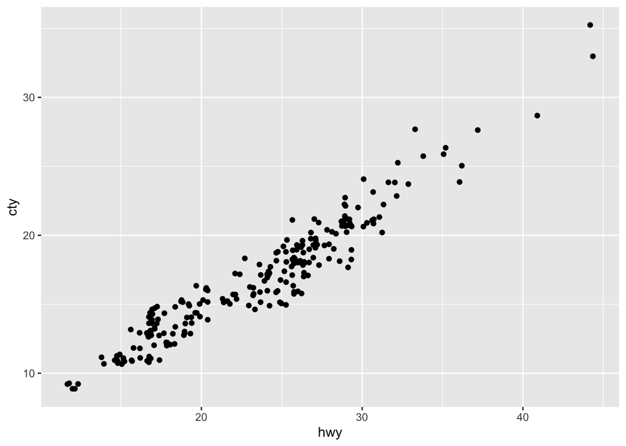

```r
# from the plot we can see they are correlating as one increases so does the other one.
ggplot(data = mpg, aes(x = hwy, y = cty)) + geom_jitter()
```

4. Apart from the US, most countries use fuel consumption (fuel consumed over fixed distance) rather than fuel economy (distance traveled with fixed amount of fuel). How could you convert `cty` and `hwy` into the European standard of liter/100 km? Introduce corresponding variables into the `mpg` data.

```r
# Miles to KM we need to divide 235.21 by the number of miles per gallon
mpg$cty.convert = 235.21 / mpg$cty
mpg$hwy.convert = 235.21 / mpg$hwy
```